# Unit 1 Live Session

w203: Statistics for Data Science

# What can you learn in this class?

- Probability theory
- Statistics
- Applying theory to data
- How statistics relates to other fields (machine learning, econometrics, political science, etc.)
- Composing a persuasive statistical analysis.

[figure not shown]

# Coordination

## Instructor Introduction

## Student Introductions

Please take 90 seconds to tell us:

- Where you dial in from
- What kind of work you do / are interested in

## Weekly Workflow

- A “typical” week in the course will proceed in the following way:
1. **Before class**: Complete all asynchronous materials. This means, watch all videos and complete all readings and concept checks.
2. **In live session**: We will work on exercises and coding that will extend your understanding.
3. **After live session**: Complete the homework for the unit. This homework will be due before the next live session.

## Resources

- [Course Webpage](http://mids-w203.github.io/syllabus)
- [ISVC](http://learn.datascience.berkeley.edu)
- [Github Org](http://github.com/mids-w203)
- [Slack](https://ucbischool.slack.com/archives/C018AT17Z4M)

## Homework

- Most weeks of the course include a homework assignment.
- To access the first homework, navigate to our Github Org
  - Open our section repository. I
  - Open the `unit_01` homework folder
- To submit the first homework, find the section on ISVC called Assessments. There is a page there to upload your solution file.

# Recommendations for Learning

## Proceed step-by-step.

- Each concept builds on previous concepts.
- Doing the reading when instructed by async.
  - We have interwoven reading and video to help you master each concept before moving on.
- If things become unclear, go back and rewatch / reread. (This is normal!)

## Build a schedule for your studying.

- Find time when you feel calm and can focus on the material.
- If possible, we recommend splitting your study time over multiple days.
  - We have divided most units into “parts” for this purpose.

## Study together.

- Schedule study sections
- Schedule peer discussion sections
- Schedule Q&A times about homework with your peers.

> **You all** – *the community of students* – **are the best resource in the program.**

## Attend Office Hours.

- You can attend the office hours of any instructor.
- You can attend as many office hours each week as you want.
- Bring your homework problems, or more general questions, or show up just to chat.

## Maximize learning, not points.

- There’s no reason to score points on assignments or tests if you haven’t learned the concept.
- The fundamentals will be important throughout MIDS and beyond.

## Software and Computing

[figure not shown]

- We will be providing all code for the course in .Rmd files.

## Datahub

- For much of the work that you do in the course, you can use the UC Berkeley provided [R Datahub](http://r.datahub.berkeley.edu) instance.
  - This is a small instance, but for a lot of the exercises we do it will be sufficient.
  - This resource has ephemeral compute (i.e. when you log-off your “state” will not be saved);
  - But, persistent storage (i.e. what you save will be available for you when you return).

## Docker

- For larger projects that you want to work on, we’d suggest using a Docker image that has solved all of the dependencies.
- Several great images are maintained by the Rstudio group and are available at [Rocker Docker Hub](https://hub.docker.com/u/rocker). In particular, the `rocker/rstudio` and `rocker/tidyverse` images are go-to images.

## Local Install

- You can install locally – most of the instructors have – but we’re not going to be able to support your install.
- See the instructions in the R Bridge Course for more.

# Probability Theory

[figure not shown]

## Probability

- Probability is a system of reasoning that we use to model the world under incomplete information
- This model underlies virtually *every* other model you’ll ever use

## Defining a Sample Space

- For each of the following experiments, how would you define the sample space, $\Omega$?
  - Rolling a six sided die
  - Drawing a five-card poker hand
  - Choosing 1,000 Berkeley students for a survey about on-campus student health and well-being

## Working with a Sample Space, Part I

1. **For one roll of a six-sided die**:
   1. What is the sample space, $\Omega$?
   2. How many elements exist in $\Omega$?
   3. What is an example of an event, $\omega$ that could occur?

## Working with a Sample Space, Part II

2. **For one roll of TWO six-sided die**:
   1. What is the sample space, $\Omega$?
   2. How many elements exist in $\Omega$?
   3. Starting from two dice with six faces – which would cause $\Omega$ increase faster: Adding a new die, or adding a new face to existing die?

## Working with a Sample Space, Part III

3. **For a 52-card poker deck (i.e. a deck that contains 13 ranks grouped by four suits)**:
   1. What is the sample space $\Omega$?
   2. How many elements exist in $\Omega$?
   3. What is an example of an event that has five cards in it?
   4. How many ways can you produce an *arbitrary* five-card event?
   5. What is the probability of getting **one** particular event?
   6. **Bonus**: What elements are in the four-card event that is the “worst hand you could have”?

## Working with a Sample Space, Part IV

4. **For a random sample of 1,000 Berkeley students**:
   1. What is the sample space, $\Omega$?
   2. How big is $\Omega$? How many elements does it contain?
   3. What is an example of an event that could occur within the sample space?
   4. Can a single person be in the space twice? Why or why not?

## Working with a Sample Sapce, Part V

5. **Suppose that you’re sitting in a surf lineup, and you have to pick a wave that is the right height. Too small, and you won’t get anywhere, too large and you’ll get crushed.**
   1. What is the sample space for wave height, $\Omega$?
   2. How big is $\Omega$? How many elements does it contain?
   3. What is an example of an event that could occur within the sample space?
   4. If you paddle at 10 waves, how large is the sample space?

# Total Probability

## Total Probability, Part I

- Below is written the law of total probability.
- Read the math aloud, and explain what it means.

$$P(B) = \sum_{i=1}^{N} P(A_{i} \cap B) = \sum_{i=1}^{N}P(B|A_{i})P(A_{i})$$

## Total Probability, Part II

- Use the law of total probability to compute the value of $P(B)$ in the following image:

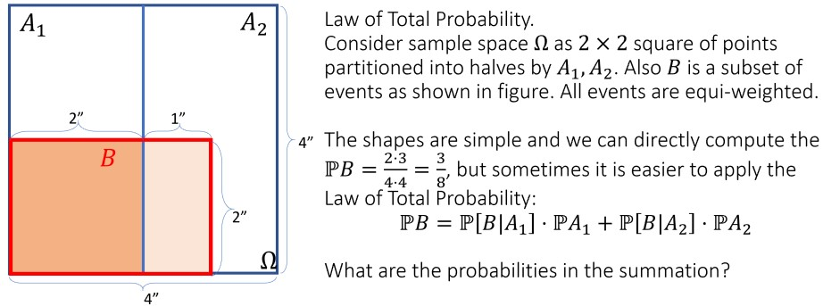

# Playing Catchup

Suppose you’re taking a statistics class and that in each week you are either caught up or behind on the readings.

- It is difficult to incorporate a new class in to your schedule so the probability that you will be caught up in Week 1, having viewed all async and completed the pre class exercises before the live session, is 0.7.
- From then on, if you are caught up in a given week, the probability that you will be caught up in the next week is 0.7.
- If you are behind in a given week, the probability that you will be caught up in the next week is 0.4.
- **What is the probability that you are caught up in week 3?**

# Fatal Office Involved Shootings

- Johnson et al. “model” purports to estimate the effect of *officer race* in officer involved shootings.

> **Claim**: “White officers are not more likely to shoot minority civilians than non-White [sic] officers.”

> **Data**: “Among those people who were shot, what proportion are minority civilians?”
- What is the difference between these two statements?
- If the claim were to be *true*, what policy action would you take?
- Because we can’t evaluate whether the claim is *true*, what would happen if you took the recommended policy action?

# Apply Bayes Theorem

# (Optional) Coronavirus Testing

## Coronavirus Testing, Part I

- Many forms of coronavirus testing works in the following way:
  - A test measures the levels of a particular immunoglobulin, if these levels are higher/lower than some threshold the test declares a qualitative assessment: positive/negative.
  - By raising the threshold that the immunoglobulin need to cross, the test will have fewer false-positive results; by lowering the threshold that the immunoglobulin need to cross the test will have fewer false-negative results.

## Coronavirus Testing, Part II

- Let $T$ be the event that a **t**est comes up positive.
- Let $C$ be the event that an individual has **c**oronavirus.
- Let $R$ be the population disease **r**ate.
- Suppose that you set the threshold on the test such that $P(T|C) = 0.94$ and $P(T^C|C^C) = 0.96$.
- Suppose that you believe the population prevelance of Coronavirus to be 10% of the population.

## Coronavirus Testing, Part III

1. What is the probability that a person has coronavirus, given they present a positive result?
2. What is the probability that a person **does not** have coronavirus, given they present a positive result?
3. What is the probability that a person has coronavirus, given than they present two positive results?
4. What is the probability that a person has coronavirus, given that they present one positive and one negative result?

## Coronavirus Testing, Part IV

- What if instead there was a lot of undetected coronavirus in the population? Rather than 10% of the population being affected, 30% of the population has the disease.
1. What is the probability that a person has coronavirus, given they present a positive result?
2. What is the probablity that a person **does not** have coronavirus, given they present a positive result?
3. Are you surprised by how much these values change?

# Reminders

1. Welcome!
2. Before next live session:
3. Complete the homework that builds on this unit; and,
4. Complete all videos and reading for unit 2.
5. Good luck getting started!